# Yulu

**About Yulu**

Yulu is India’s leading micro-mobility service provider, which offers unique vehicles for the daily commute. Starting off as a mission to eliminate traffic congestion in India, Yulu provides the safest commute solution through a user-friendly mobile app to enable shared, solo and sustainable commuting.

Yulu zones are located at all the appropriate locations (including metro stations, bus stands, office spaces, residential areas, corporate offices, etc) to make those first and last miles smooth, affordable, and convenient!

**Business Problem**

Yulu, a shared electric cycle service provider, has been experiencing a notable decline in its revenue in the Indian market. To address this challenge, Yulu has engaged a consulting firm to investigate the factors influencing the demand for shared electric cycles in India. The primary objectives of this analysis are as follows:

- Identify the significant variables that have a substantial impact on predicting the demand for shared electric cycles in the Indian market.
- Assess the effectiveness of these identified variables in describing and explaining the fluctuations in the demand for electric cycles, aiming to gain insights that will aid in devising strategies to improve revenue and market performance.

Importing necessary libraries

```python
import numpy as np
import pandas as pd
import matplotlib.pyplot as plt
import seaborn as sns
from scipy.stats import norm
```

Loading the dataset

```python
df = pd.read_csv('bike_sharing.csv')
df.head()
```

|  | datetime | season | holiday | workingday | weather | temp | atemp | humidity | windspeed | casual | registered | count |
| --- | --- | --- | --- | --- | --- | --- | --- | --- | --- | --- | --- | --- |
| 0 | 2011-01-01 00:00:00 | 1 | 0 | 0 | 1 | 9.84 | 14.395 | 81 | 0.0 | 3 | 13 | 16 |
| 1 | 2011-01-01 01:00:00 | 1 | 0 | 0 | 1 | 9.02 | 13.635 | 80 | 0.0 | 8 | 32 | 40 |
| 2 | 2011-01-01 02:00:00 | 1 | 0 | 0 | 1 | 9.02 | 13.635 | 80 | 0.0 | 5 | 27 | 32 |
| 3 | 2011-01-01 03:00:00 | 1 | 0 | 0 | 1 | 9.84 | 14.395 | 75 | 0.0 | 3 | 10 | 13 |
| 4 | 2011-01-01 04:00:00 | 1 | 0 | 0 | 1 | 9.84 | 14.395 | 75 | 0.0 | 0 | 1 | 1 |

**Column Profiling**

- datetime: datetime
- season: season (1: spring, 2: summer, 3: fall, 4: winter)
- holiday: whether day is a holiday or not (extracted from http://dchr.dc.gov/page/holiday-schedule)
- workingday: if day is neither weekend nor holiday is 1, otherwise is 0.
- weather:

  1: Clear, Few clouds, partly cloudy, partly cloudy

  2: Mist + Cloudy, Mist + Broken clouds, Mist + Few clouds, Mist

  3: Light Snow, Light Rain + Thunderstorm + Scattered clouds, Light Rain + Scattered clouds

  4: Heavy Rain + Ice Pallets + Thunderstorm + Mist, Snow + Fog
- temp: temperature in Celsius
- atemp: feeling temperature in Celsius
- humidity: humidity
- windspeed: wind speed
- casual: count of casual users
- registered: count of registered users
- count: count of total rental bikes including both casual and registered

## **Checking the structure & characteristics of the dataset**

```python
#Shape of data
df.shape
```

```
(10886, 12)
```

```python
#Columns in data
df.columns
```

```
Index(['datetime', 'season', 'holiday', 'workingday', 'weather', 'temp',
       'atemp', 'humidity', 'windspeed', 'casual', 'registered', 'count'],
      dtype='object')
```

```python
#Data types of all columns
df.dtypes
```

```
datetime       object
season          int64
holiday         int64
workingday      int64
weather         int64
temp          float64
atemp         float64
humidity        int64
windspeed     float64
casual          int64
registered      int64
count           int64
dtype: object
```

Datetime column needs to be converted into datetime datatype. Columns like 'season', 'holiday', 'workingday', 'weather' have categorical values, so we need to convert their datatype to categorical.

```python
#Conversion of datetime column from object to datetime
df['datetime'] = pd.to_datetime(df['datetime'])

#Conversion of categorical attributes to 'category'
cols  = ['season', 'holiday', 'workingday', 'weather']
df[cols] = df[cols].astype('category')
```

```python
df['season'].replace({1: 'spring',
                     2: 'summer',
                     3: 'fall',
                     4: 'winter'}, inplace = True
                      )
```

```python
df.dtypes
```

```
datetime      datetime64[ns]
season              category
holiday             category
workingday          category
weather             category
temp                 float64
atemp                float64
humidity               int64
windspeed            float64
casual                 int64
registered             int64
count                  int64
dtype: object
```

```python
#Missing value detection
df.isnull().sum()
```

```
datetime      0
season        0
holiday       0
workingday    0
weather       0
temp          0
atemp         0
humidity      0
windspeed     0
casual        0
registered    0
count         0
dtype: int64
```

```python
#Statistical summary
df.describe(include = 'all').T
```

|  | count | unique | top | freq | first | last | mean | std | min | 25% | 50% | 75% | max |
| --- | --- | --- | --- | --- | --- | --- | --- | --- | --- | --- | --- | --- | --- |
| datetime | 10886 | 10886 | 2011-01-01 00:00:00 | 1 | 2011-01-01 | 2012-12-19 23:00:00 | NaN | NaN | NaN | NaN | NaN | NaN | NaN |
| season | 10886 | 4 | winter | 2734 | NaT | NaT | NaN | NaN | NaN | NaN | NaN | NaN | NaN |
| holiday | 10886.0 | 2.0 | 0.0 | 10575.0 | NaT | NaT | NaN | NaN | NaN | NaN | NaN | NaN | NaN |
| workingday | 10886.0 | 2.0 | 1.0 | 7412.0 | NaT | NaT | NaN | NaN | NaN | NaN | NaN | NaN | NaN |
| weather | 10886.0 | 4.0 | 1.0 | 7192.0 | NaT | NaT | NaN | NaN | NaN | NaN | NaN | NaN | NaN |
| temp | 10886.0 | NaN | NaN | NaN | NaT | NaT | 20.23086 | 7.79159 | 0.82 | 13.94 | 20.5 | 26.24 | 41.0 |
| atemp | 10886.0 | NaN | NaN | NaN | NaT | NaT | 23.655084 | 8.474601 | 0.76 | 16.665 | 24.24 | 31.06 | 45.455 |
| humidity | 10886.0 | NaN | NaN | NaN | NaT | NaT | 61.88646 | 19.245033 | 0.0 | 47.0 | 62.0 | 77.0 | 100.0 |
| windspeed | 10886.0 | NaN | NaN | NaN | NaT | NaT | 12.799395 | 8.164537 | 0.0 | 7.0015 | 12.998 | 16.9979 | 56.9969 |
| casual | 10886.0 | NaN | NaN | NaN | NaT | NaT | 36.021955 | 49.960477 | 0.0 | 4.0 | 17.0 | 49.0 | 367.0 |
| registered | 10886.0 | NaN | NaN | NaN | NaT | NaT | 155.552177 | 151.039033 | 0.0 | 36.0 | 118.0 | 222.0 | 886.0 |
| count | 10886.0 | NaN | NaN | NaN | NaT | NaT | 191.574132 | 181.144454 | 1.0 | 42.0 | 145.0 | 284.0 | 977.0 |

Observations:

- There are no missing values present in dataset.
- The 'casual', 'registered' and 'count' attributes could have outliers since there is a huge difference between mean and median values. They also have high standard deviation that suggests a substantial variance in the data for these attributes.
- There are 4 unique seasons and 4 unique weather categories.

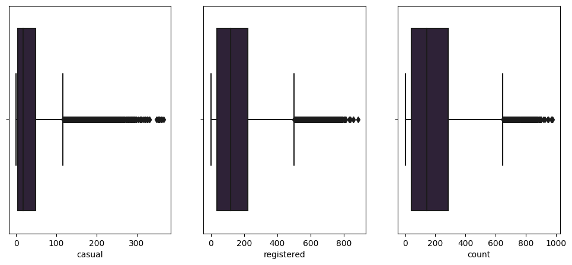

```python
# Outlier Detection
plt.figure(figsize = (12,5))
sns.set_palette('mako')
plt.subplot(1,3,1)
sns.boxplot(data = df, x = 'casual')

plt.subplot(1,3,2)
sns.boxplot(data = df, x = 'registered')

plt.subplot(1,3,3)
sns.boxplot(data = df, x = 'count')
```

- There are outliers present in columns 'casual' and 'registered' and 'count'

# **Non Graphical Analysis (Value_counts and Unique Attributes)**

```python
#Total no. of Seasons
df.season.nunique()
```

```
4
```

```python
#Count of Entries for Each Season
df.season.value_counts()
```

```
winter    2734
summer    2733
fall      2733
spring    2686
Name: season, dtype: int64
```

```python
#Total no. of Weather
df.weather.nunique()
```

```
4
```

```python
#Count of Entries for Each Weather
df.weather.value_counts()
```

```
1    7192
2    2834
3     859
4       1
Name: weather, dtype: int64
```

```python
#Count of Entries for Holidays and Non-Holidays
df.holiday.value_counts()
```

```
0    10575
1      311
Name: holiday, dtype: int64
```

```python
#Count of Entries for Working days and Non-Working days
df.workingday.value_counts()
```

```
1    7412
0    3474
Name: workingday, dtype: int64
```

# **Univariate Analysis**

Distribution plots of all the continuous variable

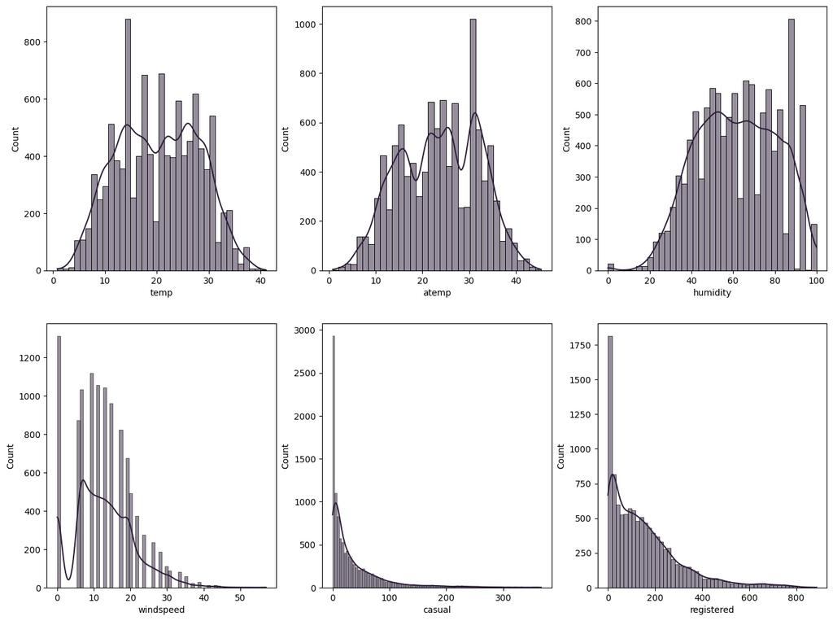

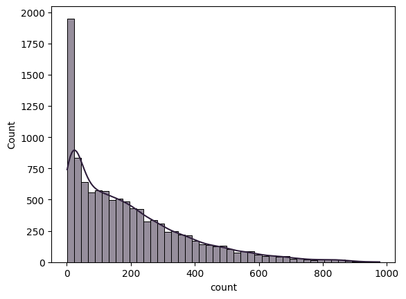

```python
cont_cols = ['temp', 'atemp', 'humidity', 'windspeed', 'casual', 'registered','count']

fig, axis = plt.subplots(nrows=2, ncols=3, figsize=(16, 12))
sns.set_palette('mako')
index = 0
for row in range(2):
    for col in range(3):
        sns.histplot(df[cont_cols[index]], ax=axis[row, col], kde=True)
        index += 1

plt.show()
sns.histplot(df[cont_cols[-1]], kde=True)
plt.show()
```

- temp, atemp, humidity appear to follow Normal Distribution.
- casual, registered and count follow Log Normal Distribution.
- windspeed follows Binomial Distribution.

Barplots/Countplots of all the categorical variables.

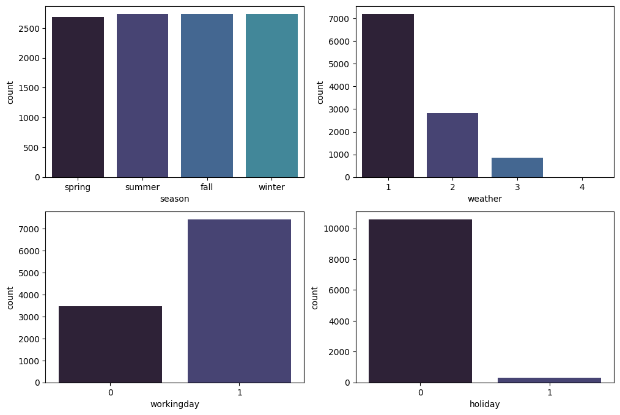

```python
plt.figure(figsize = (12,8))
sns.set_palette('mako')
plt.subplot(2,2,1)
sns.countplot(data = df, x = 'season')

plt.subplot(2,2,2)
sns.countplot(data = df, x = 'weather')

plt.subplot(2,2,3)
sns.countplot(data = df, x = 'workingday')

plt.subplot(2,2,4)
sns.countplot(data = df, x = 'holiday')
plt.show()
```

- There are equal no. of days for all seasons.
- The weather is mostly of type 1 i.e. Clear, Few clouds, partly cloudy, partly cloudy.
- There are more working days than holidays.

# **Bivariate Analysis**

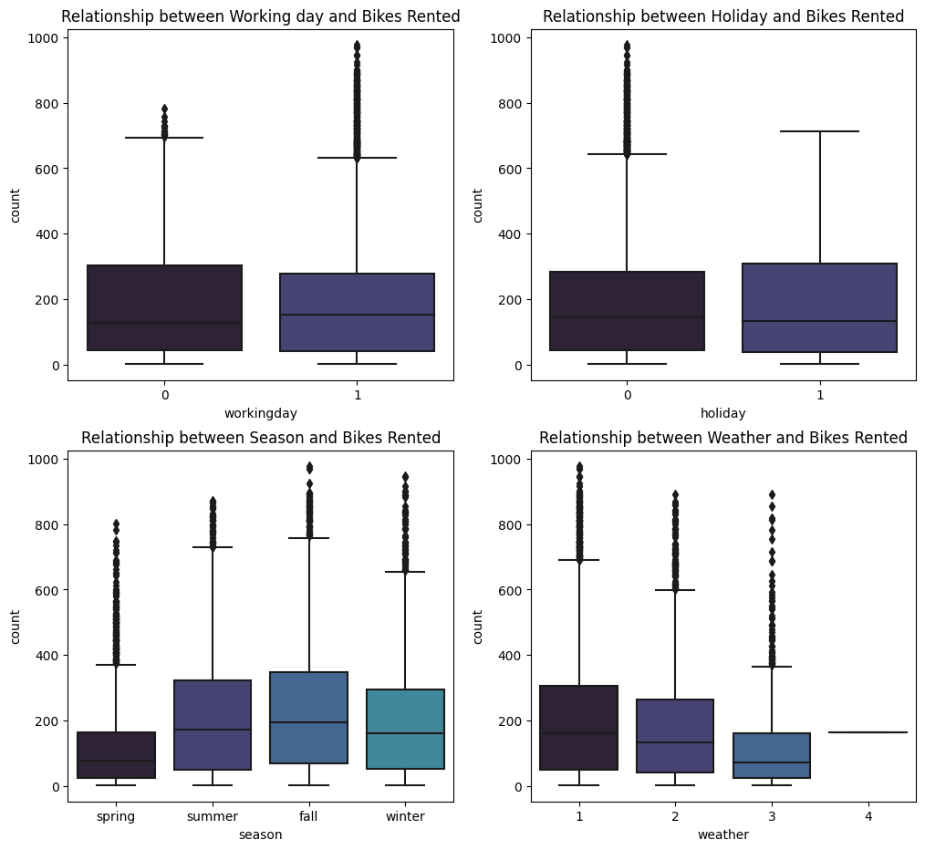

```python
#Relationship between categorical variables and bikes rented
plt.figure(figsize = (12,11))
sns.set_palette('mako')
plt.subplot(2,2,1)
plt.title('Relationship between Working day and Bikes Rented')
sns.boxplot(data = df, x = 'workingday', y = 'count')

plt.subplot(2,2,2)
plt.title('Relationship between Holiday and Bikes Rented')
sns.boxplot(data = df, x = 'holiday', y = 'count')

plt.subplot(2,2,3)
plt.title('Relationship between Season and Bikes Rented')
sns.boxplot(data = df, x = 'season', y = 'count')

plt.subplot(2,2,4)
plt.title('Relationship between Weather and Bikes Rented')
sns.boxplot(data = df, x = 'weather', y = 'count')
plt.show()
```

Here count refers to the count of total rental bikes including both casual and registered.

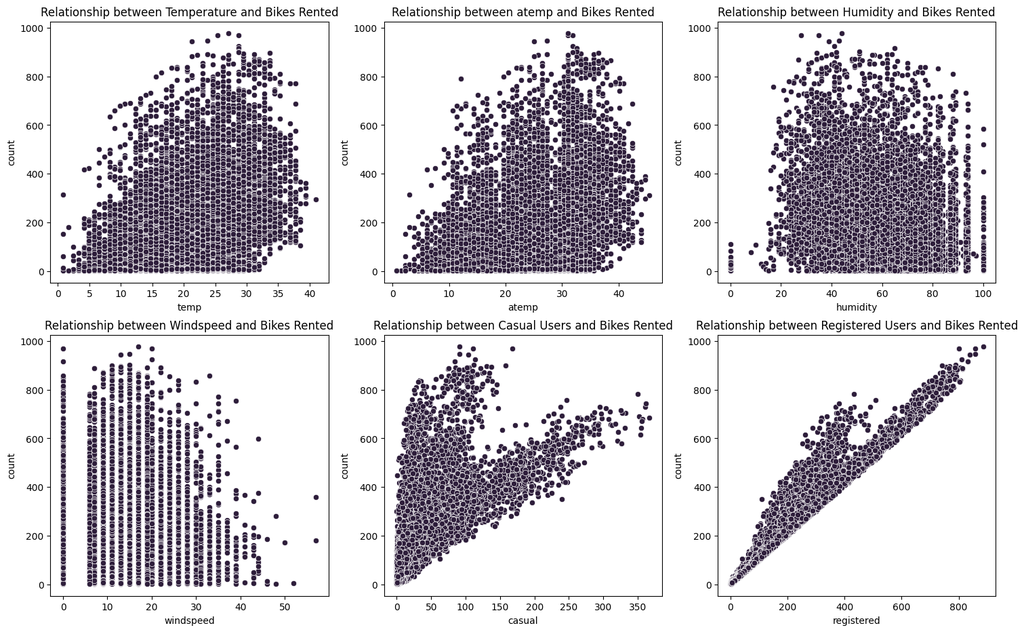

```python
#Relationship between categorical variables and Bikes Rented
plt.figure(figsize = (18,11))
sns.set_palette('mako')
plt.subplot(2,3,1)
plt.title('Relationship between Temperature and Bikes Rented')
sns.scatterplot(data=df, x='temp', y='count')
plt.subplot(2,3,2)
plt.title('Relationship between atemp and Bikes Rented')
sns.scatterplot(data=df, x='atemp', y='count')

plt.subplot(2,3,3)
plt.title('Relationship between Humidity and Bikes Rented')
sns.scatterplot(data=df, x='humidity', y='count')

plt.subplot(2,3,4)
plt.title('Relationship between Windspeed and Bikes Rented')
sns.scatterplot(data=df, x='windspeed', y='count')

plt.subplot(2,3,5)
plt.title('Relationship between Casual Users and Bikes Rented')
sns.scatterplot(data=df, x='casual', y='count')

plt.subplot(2,3,6)
plt.title('Relationship between Registered Users and Bikes Rented')
sns.scatterplot(data=df, x='registered', y='count')
plt.show()
```

- When the humidity falls below 20, the bike rental count is significantly minimal.
- Likewise, if the temperature drops below 10, the bike rental count experiences a decrease.
- Moreover, a bike rental count decline occurs when the windspeed surpasses 35.

TO CHECK CORRELATION:

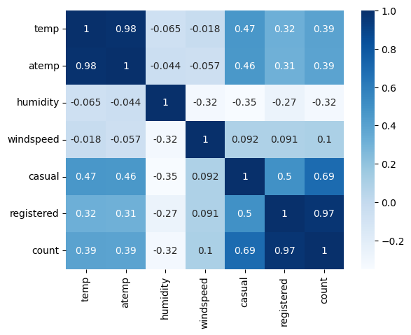

```python
#Heatmap to check correlation among numeric columns
sns.heatmap(df.corr(), annot = True, cmap = 'Blues')
plt.show()
```

- Extremely strong correlation (greater than 0.9) is evident between columns [atemp, temp] and [count, registered].
- There are no correlations with a high positive or negative strength (0.7 - 0.9) between any columns.
- Moderate positive correlations (0.5 - 0.7) can be observed between columns [casual, count] and [casual, registered].
- Low positive correlations (0.3 - 0.5) are present between columns [count, temp], [count, atemp], and [casual, atemp].
- All other combinations of columns exhibit negligible correlation

# **HYPOTHESIS TESTING**

*Hypothesis Testing 1 : To check if Working Day has an effect on the number of electric cycles rented?*

**Step 1: Setting up Null and Alternate Hypothesis.**

Null Hypothesis : Working day has no effect on number of electric cycles rented.

Alternate Hypothesis : Working day has an effect on number of electric cycles rented.

**Step 2: Checking for basic assumpitons for the hypothesis.**

```python
non_workingday = df[df['workingday']==0]['count'].values
workingday = df[df['workingday']==1]['count'].values
```

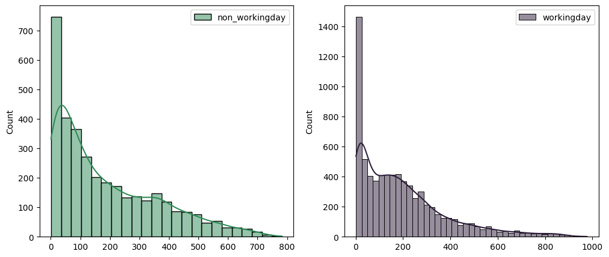

```python
#Histplot to check if the samples follow Normal distribution.
plt.figure(figsize = (12,5))
plt.subplot(1,2,1)
sns.histplot( x = non_workingday, kde = True, label = 'non_workingday', color = 'seagreen')
plt.legend()

plt.subplot(1,2,2)
sns.histplot( x = workingday, kde = True, label = 'workingday')
plt.legend()
plt.show()
```

- Both the samples do not follow Normal Distribution.

```python
#Shapiro's Test to check Homogeneity of variances.

 # Null Hypothesis(H0) - Normal Distribution
 # Alternate Hypothesis(HA) - Not Normal Distribution

from scipy.stats import shapiro
alpha = 0.05
p_value= shapiro(workingday)[1] ##To check if working days data is normal or not
print(p_value)

if p_value < 0.05:
    print('The sample does not follow normal distribution')
else:
    print('The sample follows normal distribution')
```

```
0.0
The sample does not follow normal distribution
```

```python
alpha = 0.05
p_value= shapiro(non_workingday)[1] #To check if non working days data is normal or not
print(p_value)

if p_value < 0.05:
    print('The sample does not follow normal distribution')
else:
    print('The sample follows normal distribution')
```

```
4.203895392974451e-45
The sample does not follow normal distribution
```

```python
#Levene's Test to check Homogeneity of variances.

 # Null Hypothesis(H0) - Homogenous Variance
 # Alternate Hypothesis(HA) - Non Homogenous Variance
from scipy.stats import levene
alpha = 0.05
p_value= levene(workingday, non_workingday)[1]
print(p_value)

if p_value < 0.05:
    print('The samples do not have equal variances.')
else:
    print('The samples have equal variances.')
```

```
0.9437823280916695
The samples have equal variances.
```

**Step 3: Set a significance level (alpha)**

alpha = 0.05

**Step 4: Perform 2- Sample T-Test**

```python
from scipy.stats import ttest_ind

#Null Hypothesis : Working day has no effect on number of electric cycles rented.
#Alternate Hypothesis : Working day has an effect on number of electric cycles rented.
alpha = 0.05
print(ttest_ind(workingday, non_workingday, equal_var = True))
p_value = ttest_ind(workingday, non_workingday, equal_var = True)[1]
print(p_value)
```

```
TtestResult(statistic=1.2096277376026694, pvalue=0.22644804226361348, df=10884.0)
0.22644804226361348
```

**Step 5: Inference from the analysis, Decision to accept or reject null hypothesis.**

- Since p_value > alpha, we are not able to reject Null Hypothesis.
- Hence, we conclude that Working day has no effect on number of electric cycles rented.

*Hypothesis Testing 2 : To check if No. of cycles rented is similar or different in different weather*

**Step 1: Setting up Null and Alternate Hypothesis.**

Null Hypothesis : No. of cycles rented is similar in different weather.

Alternate Hypothesis : No. of cycles rented is different in different weather.

**Step 2: Checking for basic assumpitons for the hypothesis.**

```python
df.weather.value_counts()
```

```
1    7192
2    2834
3     859
4       1
Name: weather, dtype: int64
```

```python
#Since weather 4 has only 1 value. We won't be using it for analysis as it is negligible.
```

```python
w1 = df[df['weather'] == 1]['count'].values
w2 = df[df['weather'] == 2]['count'].values
w3 = df[df['weather'] == 3]['count'].values
w4 = df[df['weather'] == 4]['count'].values
```

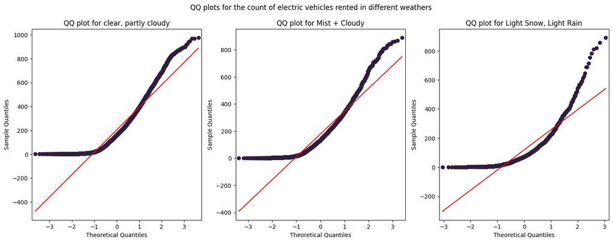

```python
#QQ Plot to check normality
from statsmodels.graphics.gofplots import qqplot
plt.figure(figsize=(18, 6))
ax1 = plt.subplot(1,3, 1)
plt.suptitle('QQ plots for the count of electric vehicles rented in different weathers')
qqplot(w1, line='s', ax=ax1)
plt.title('QQ plot for clear, partly cloudy')

ax2 = plt.subplot(1,3, 2)
qqplot(w2, line='s', ax=ax2)
plt.title('QQ plot for Mist + Cloudy')

ax3 = plt.subplot(1,3, 3)
qqplot(w3, line='s', ax=ax3)
plt.title('QQ plot for Light Snow, Light Rain')

plt.show()
```

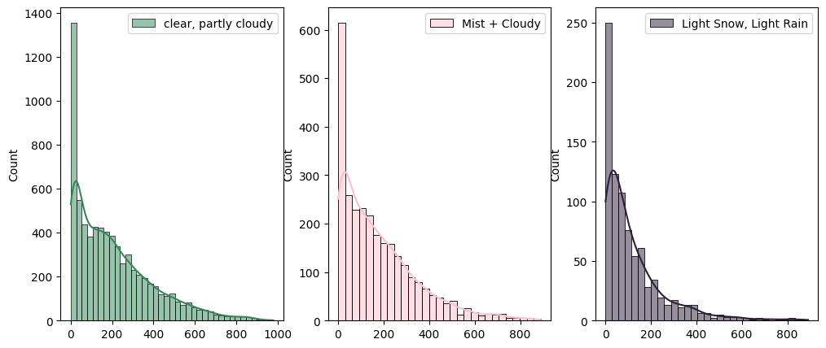

```python
#Histplot to check if the samples follow Normal distribution.
plt.figure(figsize = (12,5))
plt.subplot(1,3,1)
sns.histplot( x = w1, kde = True, label = 'clear, partly cloudy', color = 'seagreen')
plt.legend()

plt.subplot(1,3,2)
sns.histplot( x = w2, kde = True, label = 'Mist + Cloudy', color = 'pink')
plt.legend()

plt.subplot(1,3,3)
sns.histplot( x = w3, kde = True, label = 'Light Snow, Light Rain')
plt.legend()
plt.show()
```

```python
#Levene's Test to check Homogeneity of variances.

 # Null Hypothesis(H0) - Homogenous Variance
 # Alternate Hypothesis(HA) - Non Homogenous Variance
from scipy.stats import levene
alpha = 0.05
p_value= levene(w1,w2,w3,w4)[1]
print(p_value)

if p_value < 0.05:
    print('The samples do not have equal variances.')
else:
    print('The samples have equal variances.')
```

```
3.504937946833238e-35
The samples do not have equal variances.
```

**Step 3: Set a significance level (alpha)**

alpha = 0.05

**Step 4: Perform ANOVA Test**

```python
#Null Hypothesis : No. of cycles rented is similar in different weather.
#Alternate Hypothesis : No. of cycles rented is different in different weather.

from scipy.stats import f_oneway
f_oneway(w1,w2,w3,w4)
```

```
F_onewayResult(statistic=65.53024112793271, pvalue=5.482069475935669e-42)
```

**Step 5: Inference from the analysis, Decision to accept or reject null hypothesis.**

- Since p_value < alpha , we reject Null Hypothesis.
- Hence, we conclude that No. of cycles rented is different in different weather.

*Hypothesis Testing 3 : To check if No. of cycles rented is similar or different in different Seasons*

**Step 1: Setting up Null and Alternate Hypothesis.**

Null Hypothesis : No. of cycles rented is similar in different seasons.

Alternate Hypothesis : No. of cycles rented is different in different seasons.

**Step 2: Checking for basic assumpitons for the hypothesis.**

```python
winter = df[df['season'] == 'winter']['count']
summer = df[df['season']== 'summer']['count']
fall = df[df['season']== 'fall']['count']
spring = df[df['season']== 'spring']['count']
```

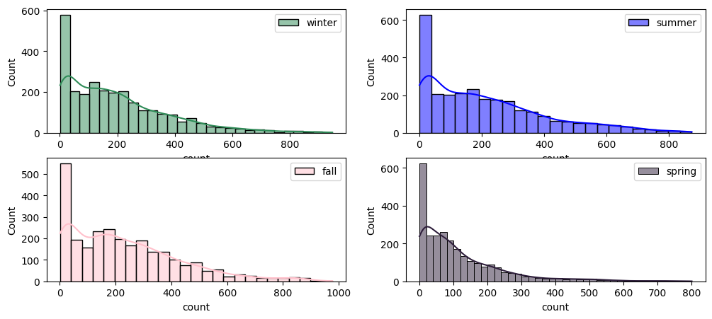

```python
#Histplot to check if the samples follow Normal distribution.
plt.figure(figsize = (12,5))
plt.subplot(2,2,1)
sns.histplot( x = winter, kde = True, label = 'winter', color = 'seagreen')
plt.legend()

plt.subplot(2,2,2)
sns.histplot( x = summer, kde = True, label = 'summer', color = 'blue')
plt.legend()

plt.subplot(2,2,3)
sns.histplot( x = fall, kde = True, label = 'fall', color = 'pink')
plt.legend()

plt.subplot(2,2,4)
sns.histplot( x = spring, kde = True, label = 'spring')
plt.legend()
plt.show()
```

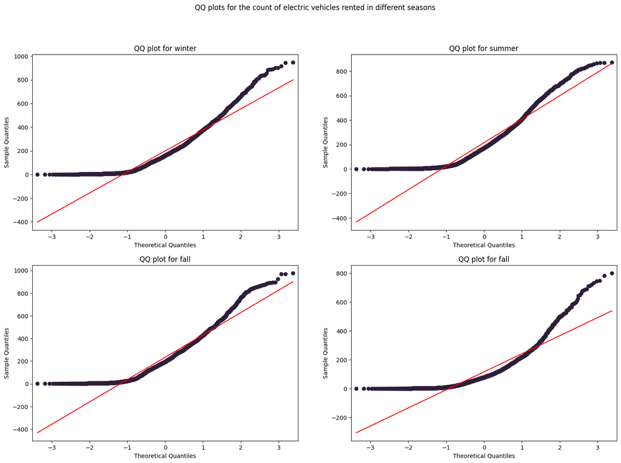

```python
#QQ Plot to check Normality of distribution
plt.figure(figsize=(18, 12))
ax1 = plt.subplot(2,2, 1)
plt.suptitle('QQ plots for the count of electric vehicles rented in different seasons')
qqplot(winter, line='s', ax=ax1)
plt.title('QQ plot for winter')

ax2 = plt.subplot(2,2, 2)
qqplot(summer, line='s', ax=ax2)
plt.title('QQ plot for summer')

ax3 = plt.subplot(2,2, 3)
qqplot(fall, line='s', ax=ax3)
plt.title('QQ plot for fall')

ax4 = plt.subplot(2,2, 4)
qqplot(spring, line='s', ax=ax4)
plt.title('QQ plot for fall')

plt.show()
```

- From above two analysis, it is clear that samples do not follow Normal Distribution.

```python
#Levene's Test to check Homogeneity of variances.

 # Null Hypothesis(H0) - Homogenous Variance
 # Alternate Hypothesis(HA) - Non Homogenous Variance
from scipy.stats import levene
alpha = 0.05
p_value= levene(winter, fall, summer, spring)[1]
print(p_value)

if p_value < 0.05:
    print('The samples do not have equal variances.')
else:
    print('The samples have equal variances.')
```

```
1.0147116860043298e-118
The samples do not have equal variances.
```

**Step 3: Set a significance level (alpha)**

alpha = 0.05

**Step 4: Perform ANOVA Test**

```python
#Null Hypothesis : No. of cycles rented is similar in different season.
#Alternate Hypothesis : No. of cycles rented is different in different season.

from scipy.stats import f_oneway
f_oneway(winter, summer, fall, spring)
```

```
F_onewayResult(statistic=236.94671081032104, pvalue=6.164843386499654e-149)
```

**Step 5: Inference from the analysis, Decision to accept or reject null hypothesis.**

- Since p_value < alpha , we reject Null Hypothesis.
- Hence, we conclude that No. of cycles rented is different in different seasons.

*Hyothesis Testing 4: To check if Weather is dependent on the season*

**Step 1: Setting up Null and Alternate Hypothesis.**

Null Hypothesis : Weather is independent of Season.

Alternate Hypothesis : Weather is dependent on Season.

**Step 2: Checking for basic assumpitons for the hypothesis.**

```python
pd.crosstab(df['season'], df['weather'], values = df['count'],aggfunc = np.sum)
```

| weather season | 1 | 2 | 3 | 4 |
| --- | --- | --- | --- | --- |
| spring | 223009 | 76406 | 12919 | 164 |
| summer | 426350 | 134177 | 27755 | 0 |
| fall | 470116 | 139386 | 31160 | 0 |
| winter | 356588 | 157191 | 30255 | 0 |

Assumptions of Chi2 Test:

1. The variables should be categorical
2. The observations must be independent of each other
3. The expected values in any cell should be greater than 5.

Here, all the three assumptions are satisfied.

**Step 3: Set a significance level (alpha)**

alpha = 0.05

**Step 4: Perform Chi-square test Test**

```python
#Null Hypothesis : Weather is independent of Season.
#Alternate Hypothesis : Weather is dependent on Season.

from scipy.stats import chi2_contingency
chi2_contingency(pd.crosstab(df['season'], df['weather'], values = df['count'],aggfunc = np.sum))
```

```
Chi2ContingencyResult(statistic=11769.559450959445, pvalue=0.0, dof=9, expected_freq=array([[2.21180553e+05, 7.59953534e+04, 1.52975188e+04, 2.45745681e+01],
       [4.16375587e+05, 1.43062351e+05, 2.87978002e+04, 4.62619795e+01],
       [4.53449224e+05, 1.55800469e+05, 3.13619255e+04, 5.03810967e+01],
       [3.85057636e+05, 1.32301826e+05, 2.66317555e+04, 4.27823557e+01]]))
```

```python
p_value = chi2_contingency(pd.crosstab(df['season'], df['weather'], values = df['count'],aggfunc = np.sum))[1]
print('pvalue =', p_value)
```

```
pvalue = 0.0
```

**Step 5: Inference from the analysis, Decision to accept or reject null hypothesis.**

- Since p_value < alpha , we reject Null Hypothesis.
- Hence, we conclude that Weather is dependent on Season.

**INSIGHTS**

**RECOMMENDATIONS**

- **Holiday Promotions**: Implement special holiday promotions or incentives to encourage higher bike rentals during holiday periods. This could include discounts, special events, or holiday-themed ride packages.
- **Seasonal Marketing**: Focus marketing efforts and promotions on the summer and fall seasons when bike rental activity is at its peak. Consider seasonal campaigns and partnerships with local events or festivals.
- **Weather-Responsive Operations**: Implement flexible bike allocation and maintenance strategies to accommodate varying weather conditions. For instance, have more bikes available during clear or partly cloudy days and reduce bike availability during light rain or snow.
- **Weather-Triggered Promotions**: Introduce weather-triggered promotions. For instance, offer discounted rides during light rain or snowy weather to encourage more rentals during these conditions.
- **Diversify Service Offerings**: Explore the possibility of diversifying your bike rental services to include weather-appropriate options. For example, offer e-bikes with weather protection during rainy or snowy days.
- **Weather-Responsive Pricing**: Consider dynamic pricing based on weather conditions. Adjust rental prices to reflect the level of inconvenience or comfort during adverse weather, which may encourage more rentals.
- **Indoor/Protected Stations**: Invest in indoor or protected bike stations at popular rental locations to attract users during heavily rainy, snowy, or thunderstorm weather.
- **Weather Information Integration**: Integrate real-time weather information into your bike rental app or website, allowing users to make informed decisions based on the current weather.
- **User Engagement during Low Humidity**: Engage users during low humidity periods by offering promotions, indoor rental options, or tips for staying comfortable during rides.
- **Windspeed Alerts**: Offer alerts or notifications to users when windspeed exceeds 35, advising them to consider alternative transportation options or ride with caution.

```python
!pip install nbconvert
```